# Model Training - CONDA Dataset

**Mickey Paulus & Roshan Saigal**

**Last Updated: November 3, 2025**

# CONDA Model Training Pipeline Description

This Python Notebook contains the code to train and evaluate classification models on the preprocessed CONDA dataset.

## What does it do?

- Loads preprocessed features and labels from the preprocessing pipeline
- Splits data into training and testing sets (80/20 split)
- Trains two classification models:
  - **Multinomial Naive Bayes**: Fast, probabilistic classifier
  - **Logistic Regression**: Linear classifier with strong performance
- Evaluates models using:
  - Accuracy Score
  - Precision, Recall, F1-Score (weighted averages)
  - Confusion Matrix
  - ROC-AUC Score
- Generates visualizations:
  - Confusion Matrix Heatmaps
  - ROC Curves
  - Model Comparison Bar Charts
- Saves trained models for later inference

This notebook depends on the preprocessing pipeline outputs:

- `preprocessing_outputs/features/X_tfidf.npz` – TF-IDF matrix
- `preprocessing_outputs/features/y.npy` – Binary labels

## 0) Set Paths for Directories

```python
# Preprocessing input paths
PREPROCESSING_DIR = "preprocessing_outputs"
FEATURES_DIR      = f"{PREPROCESSING_DIR}/features"

# Model output paths
OUTPUT_DIR    = "model_outputs"
MODELS_DIR    = f"{OUTPUT_DIR}/models"
REPORTS_DIR   = f"{OUTPUT_DIR}/reports"
PLOTS_DIR     = f"{OUTPUT_DIR}/plots"

import os
for d in [OUTPUT_DIR, MODELS_DIR, REPORTS_DIR, PLOTS_DIR]:
    os.makedirs(d, exist_ok=True)
```

## 1) Imports

```python
import pandas as pd
import numpy as np
import matplotlib.pyplot as plt
import seaborn as sns
from scipy import sparse
from joblib import dump, load

# Scikit-learn library imports
from sklearn.model_selection import train_test_split
from sklearn.naive_bayes import MultinomialNB
from sklearn.linear_model import LogisticRegression
from sklearn.metrics import (
    accuracy_score,
    precision_score,
    recall_score,
    f1_score,
    confusion_matrix,
    classification_report,
    roc_auc_score,
    roc_curve,
    auc
)

# Setting a seed for reproducibility
RANDOM_STATE = hash("I love machine learning!") % (2**32)
np.random.seed(RANDOM_STATE)
```

## 2) Load Preprocessed Data

```python
# Load TF-IDF features (sparse matrix)
X = sparse.load_npz(f"{FEATURES_DIR}/X_tfidf.npz")
print(f"Loaded TF-IDF features shape: {X.shape}")
print(f"Sparsity: {1.0 - X.nnz / (X.shape[0] * X.shape[1]):.2%}")

# Load labels
y = np.load(f"{FEATURES_DIR}/y.npy")
print(f"Loaded labels shape: {y.shape}")

# Check class distribution
unique, counts = np.unique(y, return_counts=True)
print(f"\nClass distribution:")
for label, count in zip(unique, counts):
    class_name = "Toxic" if label == 1 else "Non-Toxic"
    percentage = (count / len(y)) * 100
    print(f"  {class_name} ({label}): {count} samples ({percentage:.1f}%)")
```

```
Loaded TF-IDF features shape: (26914, 6171)
Sparsity: 99.96%
Loaded labels shape: (26914,)

Class distribution:
  Non-Toxic (0): 21694 samples (80.6%)
  Toxic (1): 5220 samples (19.4%)
```

## 3) Train-Test Split

```python
# Split data into 80% training and 20% testing
# stratify=y ensures both sets have same class distribution
X_train, X_test, y_train, y_test = train_test_split(
    X, y,
    test_size=0.2,
    random_state=RANDOM_STATE,
    stratify=y
)

print(f"Training set size: {X_train.shape[0]} samples")
print(f"Testing set size: {X_test.shape[0]} samples")
print(f"\nTraining set class distribution:")
train_unique, train_counts = np.unique(y_train, return_counts=True)
for label, count in zip(train_unique, train_counts):
    class_name = "Toxic" if label == 1 else "Non-Toxic"
    percentage = (count / len(y_train)) * 100
    print(f"  {class_name} ({label}): {count} ({percentage:.1f}%)")

print(f"\nTest set class distribution:")
test_unique, test_counts = np.unique(y_test, return_counts=True)
for label, count in zip(test_unique, test_counts):
    class_name = "Toxic" if label == 1 else "Non-Toxic"
    percentage = (count / len(y_test)) * 100
    print(f"  {class_name} ({label}): {count} ({percentage:.1f}%)")
```

```
Training set size: 21531 samples
Testing set size: 5383 samples

Training set class distribution:
  Non-Toxic (0): 17355 (80.6%)
  Toxic (1): 4176 (19.4%)

Test set class distribution:
  Non-Toxic (0): 4339 (80.6%)
  Toxic (1): 1044 (19.4%)
```

## 4) Train Multinomial Naive Bayes

```python
print("Training Multinomial Naive Bayes...")
nb_model = MultinomialNB(alpha=1.0)
nb_model.fit(X_train, y_train)
print("Multinomial Naive Bayes trained")

# Make predictions
y_pred_nb = nb_model.predict(X_test)
y_pred_proba_nb = nb_model.predict_proba(X_test)

# Save the model
dump(nb_model, f"{MODELS_DIR}/naive_bayes_model.joblib")
print(f"Model saved to {MODELS_DIR}/naive_bayes_model.joblib")
```

[output not shown]

## 5) Train Logistic Regression

```python
print("Training Logistic Regression...")
lr_model = LogisticRegression(
    max_iter=1000,
    random_state=RANDOM_STATE,
    solver='lbfgs',
    n_jobs=-1
)
lr_model.fit(X_train, y_train)
print("Logistic Regression trained")

# Make predictions
y_pred_lr = lr_model.predict(X_test)
y_pred_proba_lr = lr_model.predict_proba(X_test)

# Save the model
dump(lr_model, f"{MODELS_DIR}/logistic_regression_model.joblib")
print(f"Model saved to {MODELS_DIR}/logistic_regression_model.joblib")
```

```
Training Logistic Regression...
Logistic Regression trained
Model saved to model_outputs/models/logistic_regression_model.joblib
```

## 6) Evaluate Models

```python
def evaluate_model(y_true, y_pred, y_pred_proba, model_name):
    """
    Comprehensive model evaluation.

    Args:
        y_true: Ground truth labels
        y_pred: Predicted labels
        y_pred_proba: Predicted probabilities
        model_name: Name of the model for display

    Returns:
        Dictionary containing all metrics
    """
    accuracy = accuracy_score(y_true, y_pred)
    precision = precision_score(y_true, y_pred, average='weighted', zero_division=0)
    recall = recall_score(y_true, y_pred, average='weighted', zero_division=0)
    f1 = f1_score(y_true, y_pred, average='weighted', zero_division=0)
    roc_auc = roc_auc_score(y_true, y_pred_proba[:, 1])

    print(f"\n{'='*50}")
    print(f"{model_name} Evaluation Results")
    print(f"{'='*50}")
    print(f"Accuracy:  {accuracy:.4f}")
    print(f"Precision: {precision:.4f}")
    print(f"Recall:    {recall:.4f}")
    print(f"F1-Score:  {f1:.4f}")
    print(f"ROC-AUC:   {roc_auc:.4f}")

    return {
        'Model': model_name,
        'Accuracy': accuracy,
        'Precision': precision,
        'Recall': recall,
        'F1-Score': f1,
        'ROC-AUC': roc_auc
    }

# Evaluate both models
nb_metrics = evaluate_model(y_test, y_pred_nb, y_pred_proba_nb, "Multinomial Naive Bayes")
lr_metrics = evaluate_model(y_test, y_pred_lr, y_pred_proba_lr, "Logistic Regression")
```

```
==================================================
Multinomial Naive Bayes Evaluation Results
==================================================
Accuracy:  0.9142
Precision: 0.9160
Recall:    0.9142
F1-Score:  0.9065
ROC-AUC:   0.9116

==================================================
Logistic Regression Evaluation Results
==================================================
Accuracy:  0.9253
Precision: 0.9263
Recall:    0.9253
F1-Score:  0.9200
ROC-AUC:   0.9418
```

## 7) Classification Reports

```python
# Generate detailed classification reports
print("\n" + "="*50)
print("Multinomial Naive Bayes - Detailed Statistics")
print("="*50)
nb_report = classification_report(
    y_test, y_pred_nb,
    target_names=['Non-Toxic', 'Toxic'],
    digits=4
)
print(nb_report)

# Save to file
with open(f"{REPORTS_DIR}/classification_report_nb.txt", 'w') as f:
    f.write("Multinomial Naive Bayes - Statistics Report\n")
    f.write("="*50 + "\n")
    f.write(nb_report)

print("\n" + "="*50)
print("Logistic Regression - Detailed Statistics")
print("="*50)
lr_report = classification_report(
    y_test, y_pred_lr,
    target_names=['Non-Toxic', 'Toxic'],
    digits=4
)
print(lr_report)

# Save to file
with open(f"{REPORTS_DIR}/classification_report_lr.txt", 'w') as f:
    f.write("Logistic Regression - Statistics Report\n")
    f.write("="*50 + "\n")
    f.write(lr_report)
```

[output not shown]

## 8) Confusion Matrices

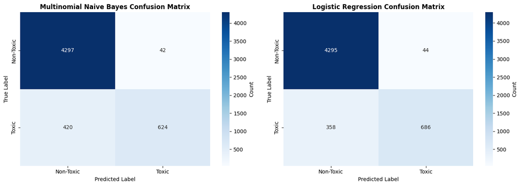

```
Confusion matrix plots saved to model_outputs/plots/confusion_matrices.png
```

```python
# Compute confusion matrices
cm_nb = confusion_matrix(y_test, y_pred_nb)
cm_lr = confusion_matrix(y_test, y_pred_lr)

# Plot confusion matrices side by side
fig, axes = plt.subplots(1, 2, figsize=(14, 5))

# Naive Bayes confusion matrix
sns.heatmap(
    cm_nb, annot=True, fmt='d', cmap='Blues',
    xticklabels=['Non-Toxic', 'Toxic'],
    yticklabels=['Non-Toxic', 'Toxic'],
    ax=axes[0],
    cbar_kws={'label': 'Count'}
)
axes[0].set_title('Multinomial Naive Bayes Confusion Matrix', fontsize=12, fontweight='bold')
axes[0].set_xlabel('Predicted Label')
axes[0].set_ylabel('True Label')

# Logistic Regression confusion matrix
sns.heatmap(
    cm_lr, annot=True, fmt='d', cmap='Blues',
    xticklabels=['Non-Toxic', 'Toxic'],
    yticklabels=['Non-Toxic', 'Toxic'],
    ax=axes[1],
    cbar_kws={'label': 'Count'}
)
axes[1].set_title('Logistic Regression Confusion Matrix', fontsize=12, fontweight='bold')
axes[1].set_xlabel('Predicted Label')
axes[1].set_ylabel('True Label')

plt.tight_layout()
plt.savefig(f"{PLOTS_DIR}/confusion_matrices.png", dpi=200, bbox_inches='tight')
plt.show()

print(f"Confusion matrix plots saved to {PLOTS_DIR}/confusion_matrices.png")
```

## 9) ROC Curves

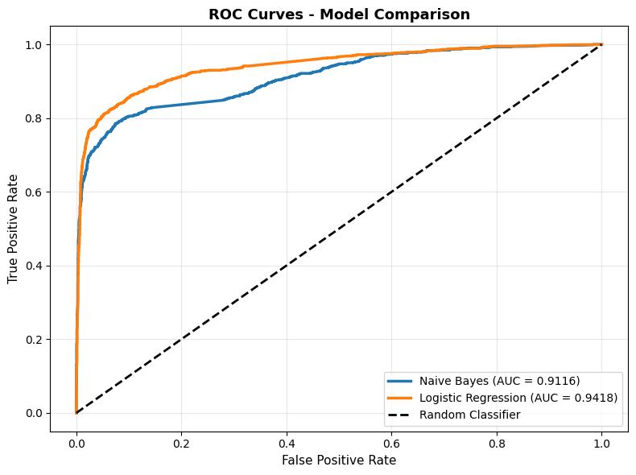

```
ROC curve plots saved to model_outputs/plots/roc_curves.png
```

```python
# Compute ROC curves
fpr_nb, tpr_nb, _ = roc_curve(y_test, y_pred_proba_nb[:, 1])
roc_auc_nb = auc(fpr_nb, tpr_nb)

fpr_lr, tpr_lr, _ = roc_curve(y_test, y_pred_proba_lr[:, 1])
roc_auc_lr = auc(fpr_lr, tpr_lr)

# Plot ROC curves
plt.figure(figsize=(8, 6))

plt.plot(
    fpr_nb, tpr_nb,
    label=f'Naive Bayes (AUC = {roc_auc_nb:.4f})',
    linewidth=2.5
)
plt.plot(
    fpr_lr, tpr_lr,
    label=f'Logistic Regression (AUC = {roc_auc_lr:.4f})',
    linewidth=2.5
)
plt.plot([0, 1], [0, 1], 'k--', linewidth=2, label='Random Classifier')

plt.xlabel('False Positive Rate', fontsize=11)
plt.ylabel('True Positive Rate', fontsize=11)
plt.title('ROC Curves - Model Comparison', fontsize=13, fontweight='bold')
plt.legend(loc='lower right', fontsize=10)
plt.grid(alpha=0.3)

plt.tight_layout()
plt.savefig(f"{PLOTS_DIR}/roc_curves.png", dpi=200, bbox_inches='tight')
plt.show()

print(f"ROC curve plots saved to {PLOTS_DIR}/roc_curves.png")
```

## 10) Model Comparison

```python
# Comparison dataframe
comparison_df = pd.DataFrame([nb_metrics, lr_metrics])
comparison_df = comparison_df.set_index('Model')

# Save comparison to CSV
comparison_df.to_csv(f"{REPORTS_DIR}/model_comparison.csv")

print("\n" + "="*60)
print("Model Comparison Summary")
print("="*60)
print(comparison_df.round(4))
print(f"\nComparison saved to {REPORTS_DIR}/model_comparison.csv")
```

```
============================================================
Model Comparison Summary
============================================================
                         Accuracy  Precision  Recall  F1-Score  ROC-AUC
Model
Multinomial Naive Bayes    0.9142     0.9160  0.9142    0.9065   0.9116
Logistic Regression        0.9253     0.9263  0.9253    0.9200   0.9418

Comparison saved to model_outputs/reports/model_comparison.csv
```

## 11) Visualize Model Comparison

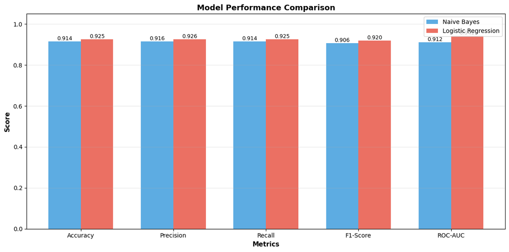

```
Model comparison metrics plot saved to model_outputs/plots/model_comparison.png
```

```python
# Create bar chart comparing metrics
metrics = ['Accuracy', 'Precision', 'Recall', 'F1-Score', 'ROC-AUC']
nb_values = [nb_metrics['Accuracy'], nb_metrics['Precision'], nb_metrics['Recall'], nb_metrics['F1-Score'], nb_metrics['ROC-AUC']]
lr_values = [lr_metrics['Accuracy'], lr_metrics['Precision'], lr_metrics['Recall'], lr_metrics['F1-Score'], lr_metrics['ROC-AUC']]

x = np.arange(len(metrics))
width = 0.35

fig, ax = plt.subplots(figsize=(12, 6))

bars1 = ax.bar(x - width/2, nb_values, width, label='Naive Bayes', alpha=0.8, color='#3498db')
bars2 = ax.bar(x + width/2, lr_values, width, label='Logistic Regression', alpha=0.8, color='#e74c3c')

# Add value labels on bars
for bars in [bars1, bars2]:
    for bar in bars:
        height = bar.get_height()
        ax.text(
            bar.get_x() + bar.get_width()/2., height,
            f'{height:.3f}',
            ha='center', va='bottom', fontsize=9
        )

ax.set_xlabel('Metrics', fontsize=11, fontweight='bold')
ax.set_ylabel('Score', fontsize=11, fontweight='bold')
ax.set_title('Model Performance Comparison', fontsize=13, fontweight='bold')
ax.set_xticks(x)
ax.set_xticklabels(metrics)
ax.legend(fontsize=10)
ax.set_ylim([0, 1.05])
ax.grid(axis='y', alpha=0.3)

plt.tight_layout()
plt.savefig(f"{PLOTS_DIR}/model_comparison.png", dpi=200, bbox_inches='tight')
plt.show()

print(f"Model comparison metrics plot saved to {PLOTS_DIR}/model_comparison.png")
```

## 12) Summary and Best Model

```python
print("\n" + "="*60)
print("TRAINING SUMMARY")
print("="*60)

print(f"\nDataset Statistics:")
print(f"  Total samples: {len(y)}")
print(f"  Training samples: {len(y_train)}")
print(f"  Testing samples: {len(y_test)}")
print(f"  Feature dimensions: {X.shape[1]}")

print(f"\nModel Performance:")
print(f"  Naive Bayes - Accuracy: {nb_metrics['Accuracy']:.4f}, ROC-AUC: {nb_metrics['ROC-AUC']:.4f}")
print(f"  Logistic Regression - Accuracy: {lr_metrics['Accuracy']:.4f}, ROC-AUC: {lr_metrics['ROC-AUC']:.4f}")

# Determine best model
best_model = "Logistic Regression" if lr_metrics['F1-Score'] > nb_metrics['F1-Score'] else "Naive Bayes"
print(f"\nBest Model: {best_model}")
print(f"F1-Score ({max(lr_metrics['F1-Score'], nb_metrics['F1-Score']):.4f})")
```

[output not shown]